# Project 1 - Part C

John Kellogg

3/29/2021

## Part 2 - Forecasting Waterflow

### Assignment Question

Part C consists of two data sets. These are simple 2 columns sets, however they have different time stamps. Your optional assignment is to time-base sequence the data and aggregate based on hour (example of what this looks like, follows). Note for multiple recordings within an hour, take the mean. Then to determine if the data is stationary and can it be forecast. If so, provide a week forward forecast and present results via RPubs and .rmd and the forecast in an Excel readable file.

**Note** As this optional assignment is mainly focused on data management and determining if it is better to forecast the pipes together or separate, I will be using the auto-arima function.

### Data Ingest

```r
data_raw_1 <- read_excel ('./data/Waterflow_Pipe1.xlsx', col_names = TRUE, col_types = c("date", "numeric"))
data_raw_2 <- read_excel ('./data/Waterflow_Pipe2.xlsx', col_names = TRUE, col_types = c("date", "numeric"))

colnames(data_raw_1)= c("DateTime", "FLOW")
colnames(data_raw_2)= c("DateTime", "FLOW")
```

### Pipe 1

#### Data Management

```r
pipe1 <- data_raw_1
```

```r
pipe1 <- pipe1%>%
  mutate(Date = date(DateTime),
         Hour = hour(DateTime)+1)%>%
  group_by(Date, Hour)%>%
  summarise(FLOW = mean(FLOW))%>%
  ungroup()%>%
  mutate(DateTime = ymd_h(paste(Date, Hour)))%>%
  select(DateTime, FLOW)
head(pipe1)
```

```
## # A tibble: 6 x 2
##   DateTime             FLOW
##   <dttm>              <dbl>
## 1 2015-10-23 01:00:00  26.1
## 2 2015-10-23 02:00:00  18.9
## 3 2015-10-23 03:00:00  15.2
## 4 2015-10-23 04:00:00  23.1
## 5 2015-10-23 05:00:00  15.5
## 6 2015-10-23 06:00:00  22.7
```

- The data is now in a standard DateTime
- I created the Mean value of each hour within the dataset

```r
summary(pipe1)
```

```
##     DateTime                        FLOW
##  Min.   :2015-10-23 01:00:00   Min.   : 8.923
##  1st Qu.:2015-10-25 11:45:00   1st Qu.:17.033
##  Median :2015-10-27 23:30:00   Median :19.784
##  Mean   :2015-10-27 23:38:53   Mean   :19.893
##  3rd Qu.:2015-10-30 11:15:00   3rd Qu.:22.789
##  Max.   :2015-11-02 00:00:00   Max.   :31.730
```

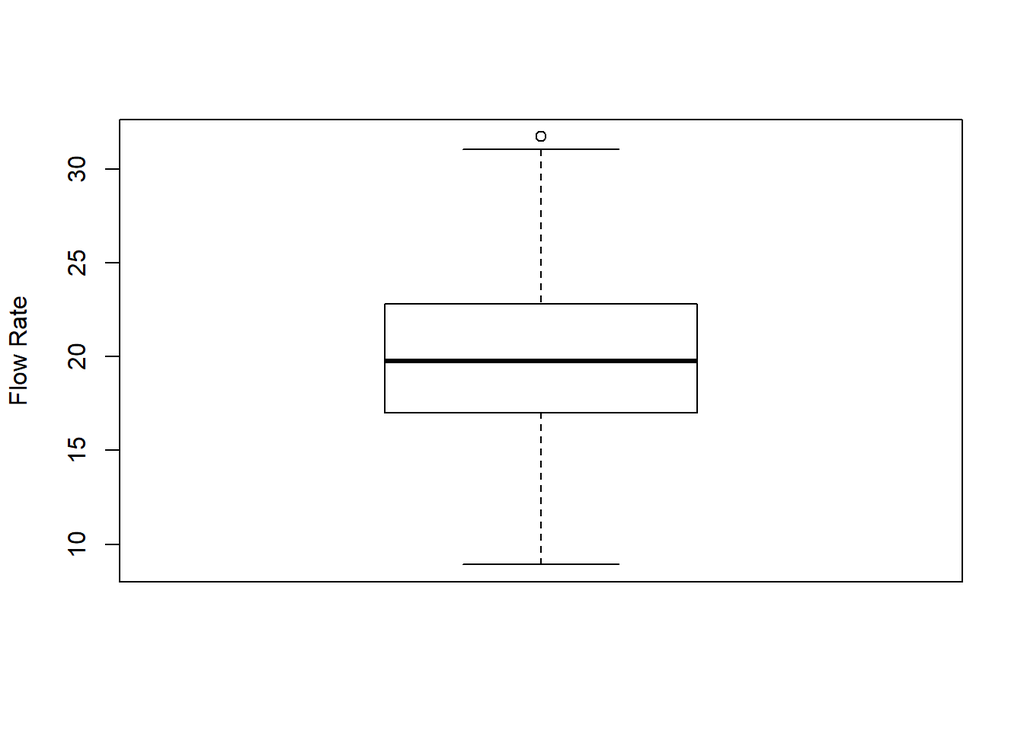

```r
boxplot(pipe1$FLOW,
        ylab = "Flow Rate")
```

```r
out <- boxplot.stats(pipe1$FLOW)$out
out
```

```
## [1] 31.72993
```

- There is an outlier but it’s not too far outside the range of the 3rd Q. I will leave it.

#### Time Series and transforms

```r
tspipe1 <- ts(pipe1$FLOW, frequency = 24, start = c(2015,1))
```

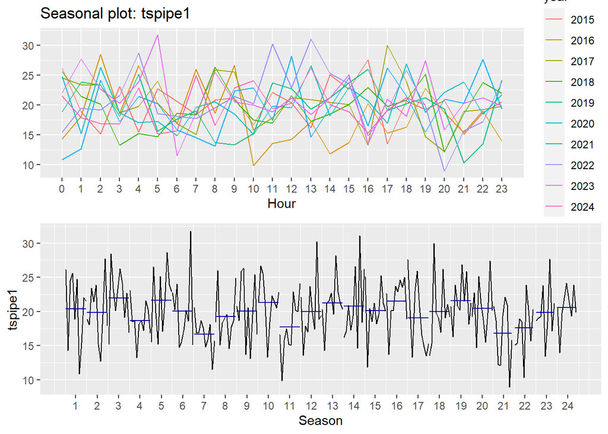

```r
grid.arrange(nrow=2,
  ggseasonplot(tspipe1),
  ggsubseriesplot(tspipe1))
```

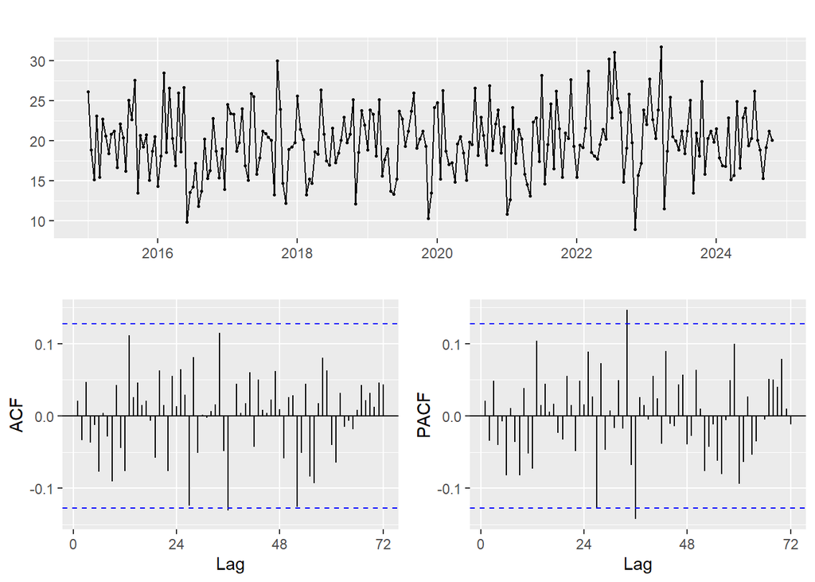

```r
ggtsdisplay(tspipe1)
```

```r
#ndiffs(tspipe1)
```

```r
tspipe1 %>% ur.kpss %>% summary
```

```
##
## #######################
## # KPSS Unit Root Test #
## #######################
##
## Test is of type: mu with 4 lags.
##
## Value of test-statistic is: 0.2466
##
## Critical value for a significance level of:
##                 10pct  5pct 2.5pct  1pct
## critical values 0.347 0.463  0.574 0.739
```

```r
tspipe1_lambda <- BoxCox.lambda(tspipe1)
auto_pipe1 <- auto.arima(tspipe1, approximation = FALSE, lambda = tspipe1_lambda)
summary(auto_pipe1)
```

```
## Series: tspipe1
## ARIMA(0,0,0) with non-zero mean
## Box Cox transformation: lambda= 0.8414107
##
## Coefficients:
##          mean
##       13.4802
## s.e.   0.1718
##
## sigma^2 estimated as 6.993:  log likelihood=-563.86
## AIC=1131.73   AICc=1131.78   BIC=1138.66
##
## Training set error measures:
##                      ME     RMSE      MAE       MPE    MAPE      MASE
## Training set 0.07255518 4.231758 3.331073 -4.680888 18.2215 0.6843644
##                    ACF1
## Training set 0.02101267
```

- Auto Arima returned with (0,0,0)
- If I put in the value of d=1, the model returns with (5,1,0)
  - However, as the Diff check stated there was no diff required, forcing a first order diff may be over-fitting the model

### Pipe 2

#### Data Management

```r
pipe2 <- data_raw_2
```

```r
summary(pipe2)
```

```
##     DateTime                        FLOW
##  Min.   :2015-10-23 01:00:00   Min.   : 1.885
##  1st Qu.:2015-11-02 10:45:00   1st Qu.:28.140
##  Median :2015-11-12 20:30:00   Median :39.682
##  Mean   :2015-11-12 20:30:00   Mean   :39.556
##  3rd Qu.:2015-11-23 06:15:00   3rd Qu.:50.782
##  Max.   :2015-12-03 16:00:00   Max.   :78.303
```

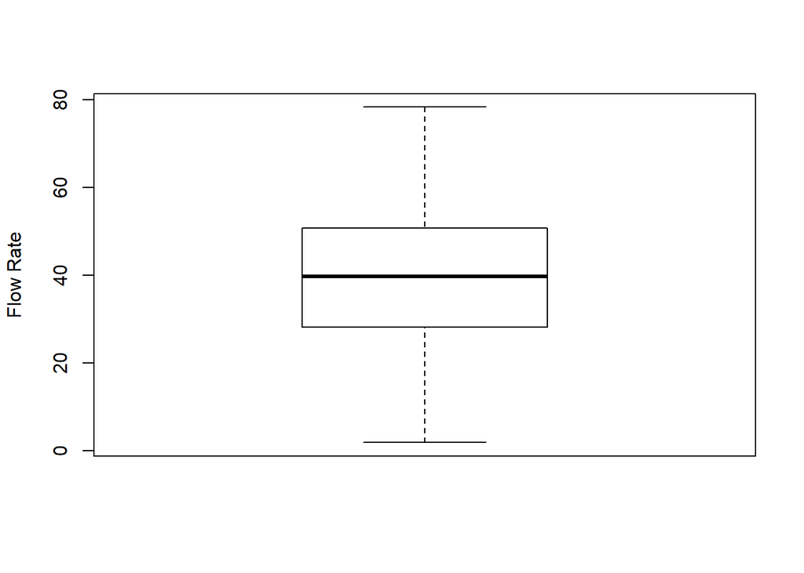

```r
boxplot(pipe2$FLOW,
        ylab = "Flow Rate")
```

```r
out <- boxplot.stats(pipe2$FLOW)$out
out
```

```
## numeric(0)
```

- No major outliers
- Data was already in a single value for each hour
- Ensured the Date/Time format matched Pipe 1

#### Time Series and Transforms

```r
tspipe2 <- ts(pipe2$FLOW, frequency = 24, start = c(2015,1))
```

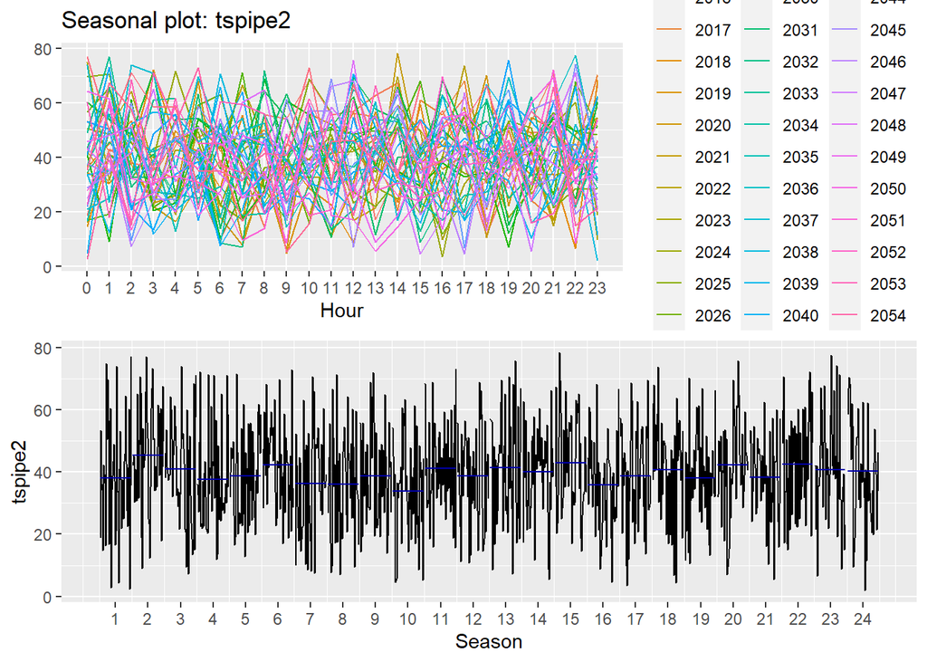

```r
grid.arrange(nrow=2,
  ggseasonplot(tspipe2),
  ggsubseriesplot(tspipe2))
```

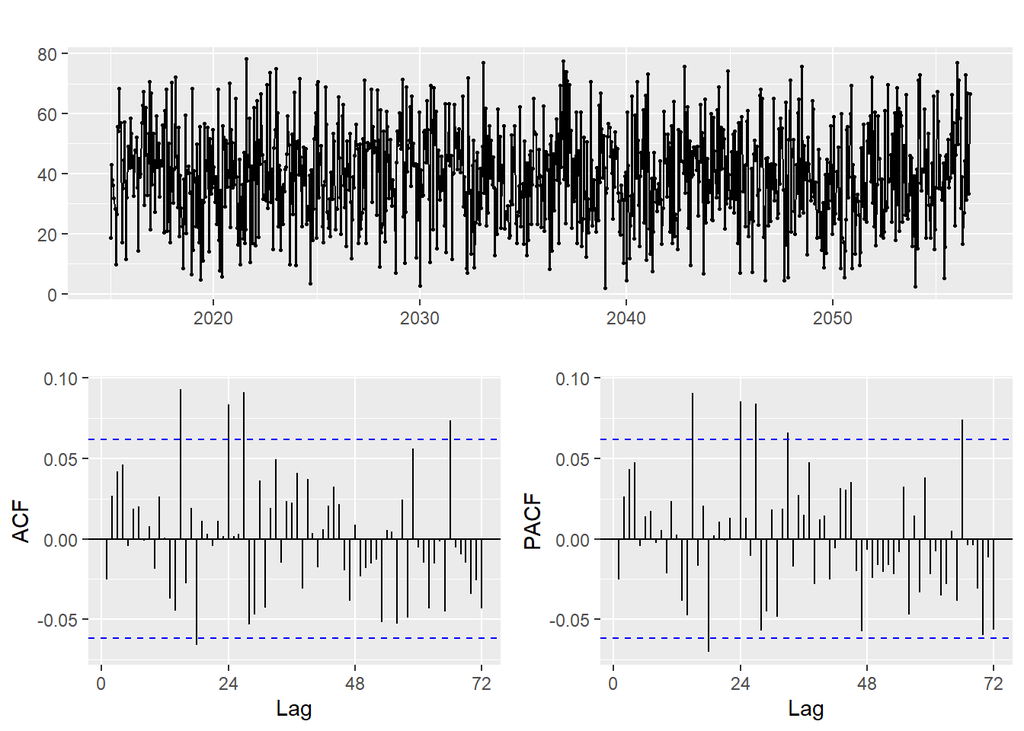

```r
ggtsdisplay(tspipe2)
```

```r
#ndiffs(tspipe2)
```

- ndiffs stated O diffs required
- Data seems to be near white noise and stationary without any changes
- We do have significant lags (specifically around lag 15)

```r
tspipe2 %>% ur.kpss %>% summary
```

```
##
## #######################
## # KPSS Unit Root Test #
## #######################
##
## Test is of type: mu with 7 lags.
##
## Value of test-statistic is: 0.1054
##
## Critical value for a significance level of:
##                 10pct  5pct 2.5pct  1pct
## critical values 0.347 0.463  0.574 0.739
```

```r
tspipe2_lambda <- BoxCox.lambda(tspipe2)
auto_pipe2 <- auto.arima(tspipe2, approximation = FALSE, lambda = tspipe2_lambda)
summary(auto_pipe2)
```

```
## Series: tspipe2
## ARIMA(0,0,0)(1,0,0)[24] with non-zero mean
## Box Cox transformation: lambda= 0.9447974
##
## Coefficients:
##         sar1     mean
##       0.0861  32.9725
## s.e.  0.0320   0.4525
##
## sigma^2 estimated as 172.1:  log likelihood=-3992.06
## AIC=7990.13   AICc=7990.15   BIC=8004.85
##
## Training set error measures:
##                    ME     RMSE      MAE       MPE     MAPE      MASE
## Training set 0.193946 15.98305 13.05623 -33.92608 56.91807 0.7504193
##                     ACF1
## Training set -0.02616276
```

- Interesting the auto model is mostly the same with a seasonal variant added.
- Again with Order of first-differencing (d=1) added, the model returned with (5,1,0)(1,0,0)
  - I think this is over-fit and over worked.

### Pipes Joined

#### Data Management

```r
pipe_join <- rbind(pipe1, pipe2)

pipe_join <- pipe_join%>%
  mutate(Date = date(DateTime),
         Hour = hour(DateTime)+1)%>%
  group_by(Date, Hour)%>%
  summarise(FLOW = mean(FLOW))%>%
  ungroup()%>%
  mutate(DateTime = ymd_h(paste(Date, Hour)))%>%
  select(DateTime, FLOW)
head(pipe_join)
```

```
## # A tibble: 6 x 2
##   DateTime             FLOW
##   <dttm>              <dbl>
## 1 2015-10-23 02:00:00  22.5
## 2 2015-10-23 03:00:00  31.0
## 3 2015-10-23 04:00:00  26.6
## 4 2015-10-23 05:00:00  29.6
## 5 2015-10-23 06:00:00  23.7
## 6 2015-10-23 07:00:00  25.5
```

```r
summary(pipe_join)
```

```
##     DateTime                        FLOW
##  Min.   :2015-10-23 02:00:00   Min.   : 1.885
##  1st Qu.:2015-11-02 11:45:00   1st Qu.:26.374
##  Median :2015-11-12 21:30:00   Median :35.728
##  Mean   :2015-11-12 21:30:00   Mean   :37.229
##  3rd Qu.:2015-11-23 07:15:00   3rd Qu.:47.131
##  Max.   :2015-12-03 17:00:00   Max.   :77.388
```

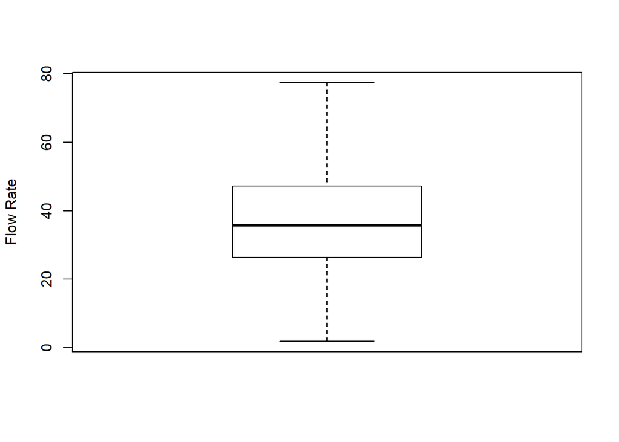

```r
boxplot(pipe_join$FLOW,
        ylab = "Flow Rate")
```

```r
out <- boxplot.stats(pipe_join$FLOW)$out
out
```

```
## numeric(0)
```

#### Time Series and Transforms

```r
tspipeall <- ts(pipe_join$FLOW, frequency = 24, start = c(2015,1))
```

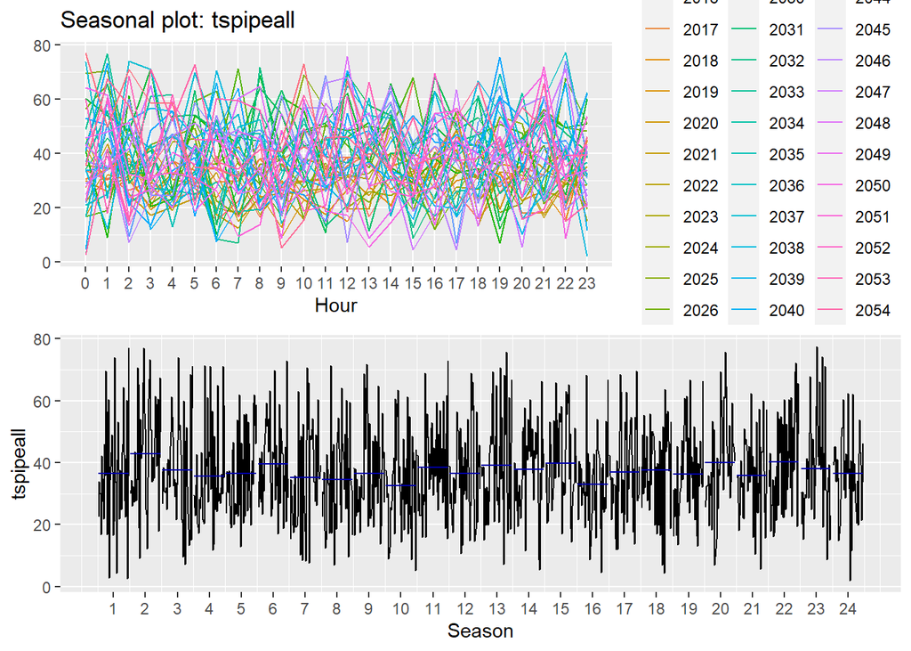

```r
grid.arrange(nrow=2,
  ggseasonplot(tspipeall),
  ggsubseriesplot(tspipeall))
```

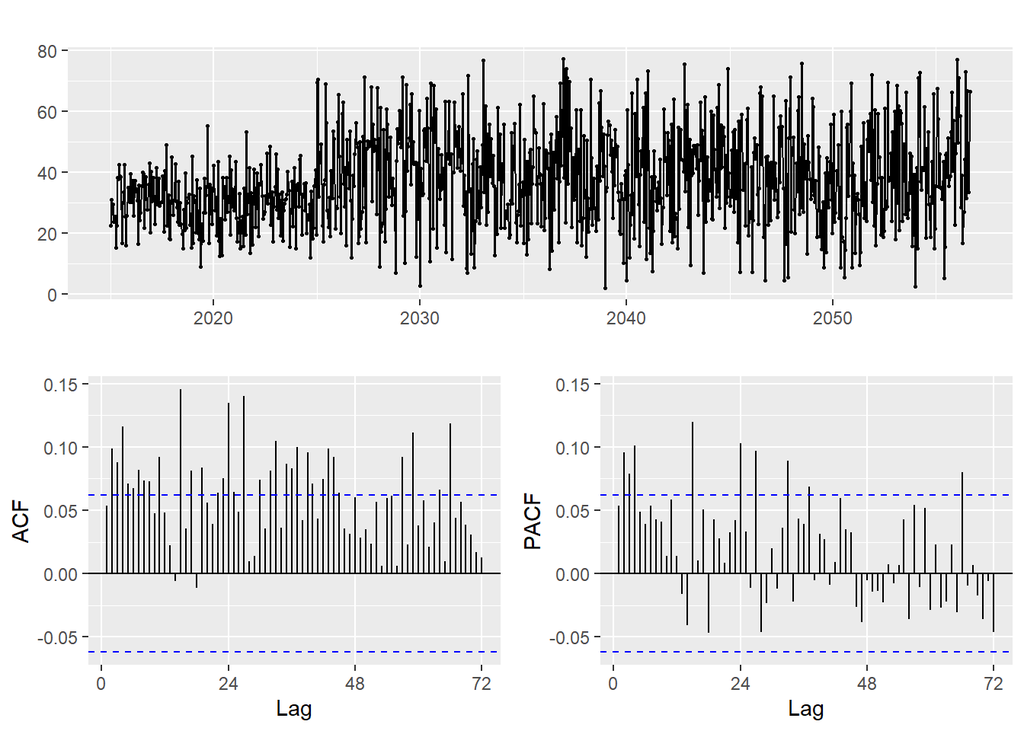

```r
ggtsdisplay(tspipeall)
```

```r
#ndiffs(tspipeall)
```

```r
tspipeall %>% ur.kpss %>% summary
```

```
##
## #######################
## # KPSS Unit Root Test #
## #######################
##
## Test is of type: mu with 7 lags.
##
## Value of test-statistic is: 2.3359
##
## Critical value for a significance level of:
##                 10pct  5pct 2.5pct  1pct
## critical values 0.347 0.463  0.574 0.739
```

- ndiffs stated 1 diffs required
- Difficult to tell if the data is near white noise and stationary without any changes

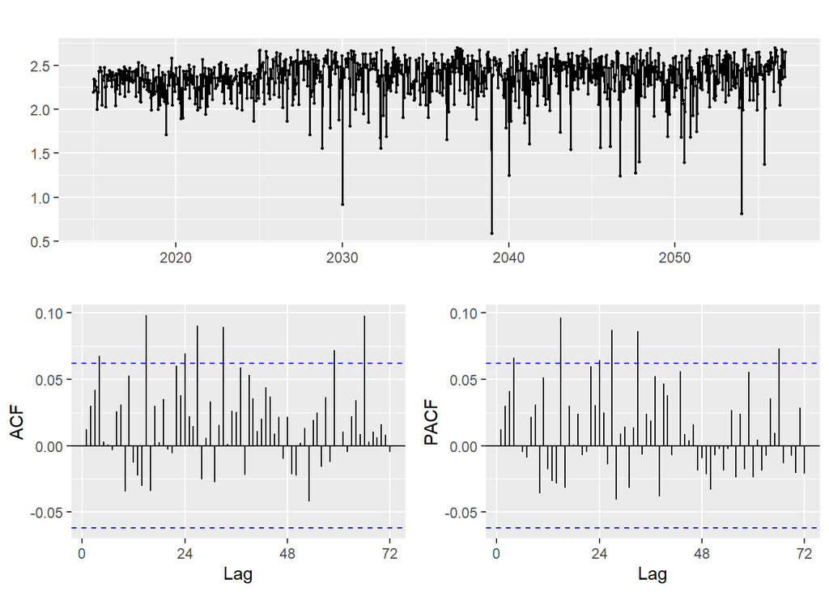

```r
lambda <- BoxCox.lambda(tspipeall)
ggtsdisplay(tspipeall  %>% BoxCox(lambda))
```

```r
ur.kpss(tspipeall %>% BoxCox(lambda) %>% diff()) %>% summary
```

```
##
## #######################
## # KPSS Unit Root Test #
## #######################
##
## Test is of type: mu with 7 lags.
##
## Value of test-statistic is: 0.0053
##
## Critical value for a significance level of:
##                 10pct  5pct 2.5pct  1pct
## critical values 0.347 0.463  0.574 0.739
```

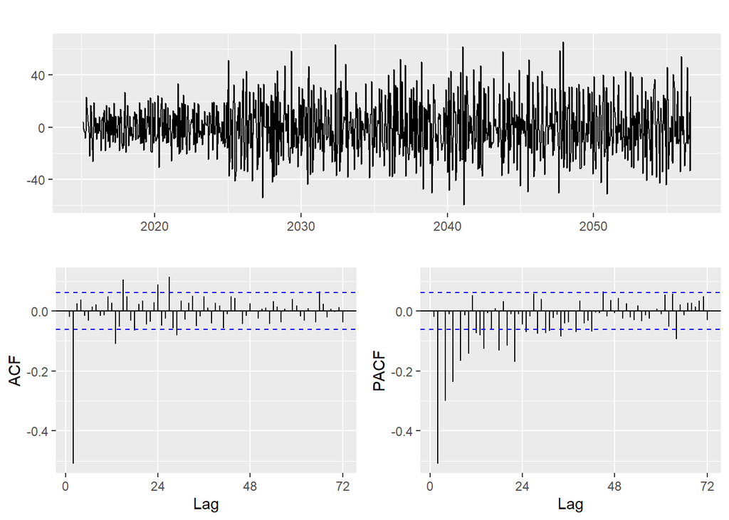

```r
ggtsdisplay(diff(tspipeall, 2), points = FALSE)
```

```r
autopipe_all <- auto.arima(tspipeall, lambda = lambda, approximation = FALSE)
summary(autopipe_all)
```

```
## Series: tspipeall
## ARIMA(0,1,1)(1,0,0)[24]
## Box Cox transformation: lambda= -0.2394658
##
## Coefficients:
##           ma1    sar1
##       -0.9862  0.0548
## s.e.   0.0067  0.0319
##
## sigma^2 estimated as 0.05379:  log likelihood=41.56
## AIC=-77.13   AICc=-77.1   BIC=-62.41
##
## Training set error measures:
##                    ME     RMSE      MAE       MPE     MAPE      MASE
## Training set 4.925571 15.58797 12.31813 -12.29636 45.51632 0.7888465
##                      ACF1
## Training set -0.003024184
```

- Pipe 1 (0,0,0)
- Pipe 2 (0,0,0)(1,0,0)[24]
- Combined (0,1,1)(1,0,0)[24]

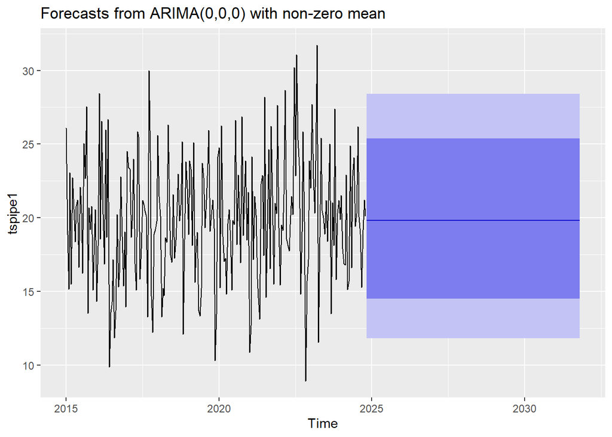

```r
pipe_forecast_1 <- forecast(auto_pipe1, h = 7*24)
autoplot(pipe_forecast_1)
```

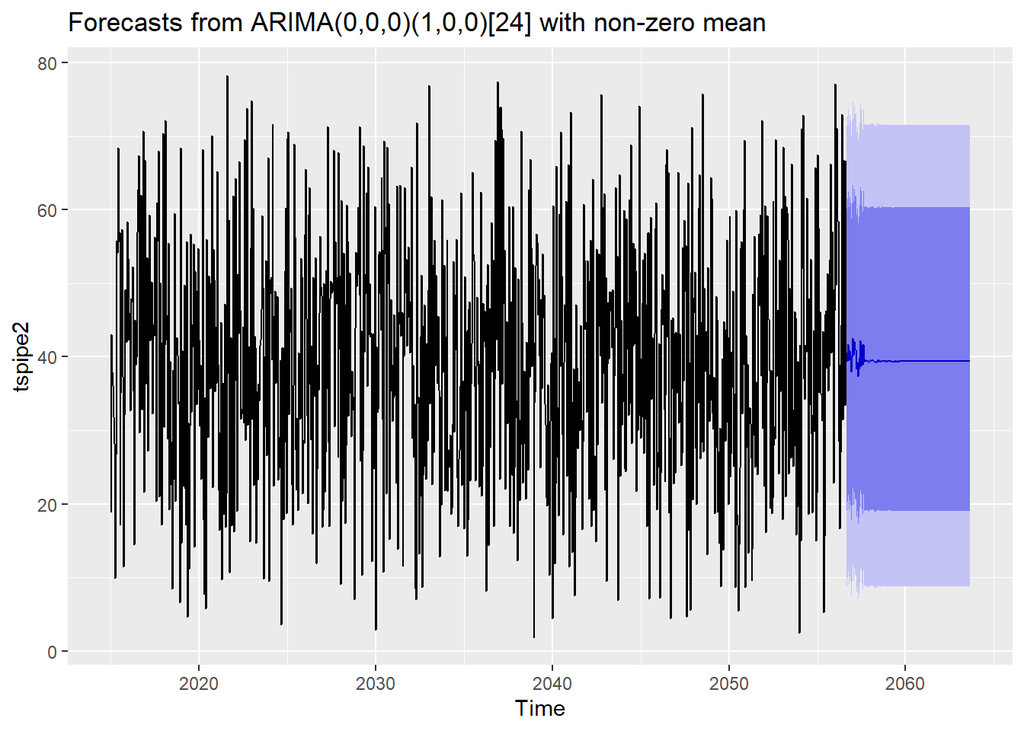

```r
pipe_forecast_2 <- forecast(auto_pipe2, h = 7*24)
autoplot(pipe_forecast_2)
```

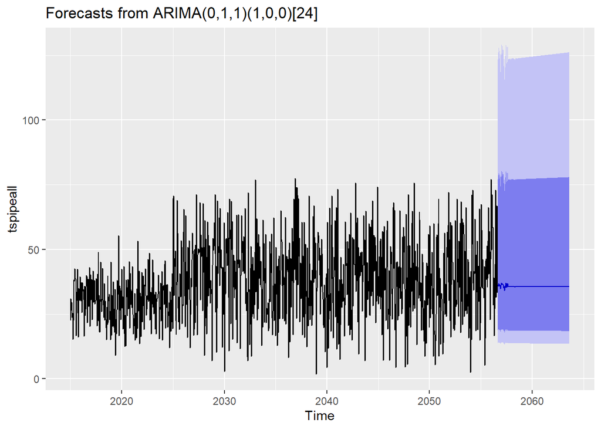

```r
pipe_forecast_3 <- forecast(autopipe_all, h = 7*24)
autoplot(pipe_forecast_3)
```

- Without knowing the infrastructure behind the pipes (are they sub-pipes from a master pipe, are they parallel pipes, etc…) I would caution combining the two.
- The Forecasts from the individual pipes is cleaner